# Question

Let function $f$ represent a cubic polynomial function with **integer** coefficients.

$$f(x)~=~ax^3+bx^2+cx+d$$

That function has a real root $x=\frac{5}{7}$ and a complex root $x=-2-3i$.

$$f\left(\frac{5}{7}\right)~=~0$$
$$f(-2-3i)~=~0$$

Assuming $a>0$ and $a$ is the smallest possible integer with those given roots, find all the coefficients.

- $a=$ ##ANSWER1##
- $b=$ ##ANSWER2##
- $c=$ ##ANSWER3##
- $d=$ ##ANSWER4##

## Answerlist

- -91
- -75
- -71
- -65
- -35
- -33
- -25
- -23
- -19
- -13
- -9
- -7
- -5
- -1
- 0
- 1
- 5
- 7
- 9
- 13
- 19
- 23
- 25
- 33
- 35
- 65
- 71
- 75
- 91
- -91
- -75
- -71
- -65
- -35
- -33
- -25
- -23
- -19
- -13
- -9
- -7
- -5
- -1
- 0
- 1
- 5
- 7
- 9
- 13
- 19
- 23
- 25
- 33
- 35
- 65
- 71
- 75
- 91
- -91
- -75
- -71
- -65
- -35
- -33
- -25
- -23
- -19
- -13
- -9
- -7
- -5
- -1
- 0
- 1
- 5
- 7
- 9
- 13
- 19
- 23
- 25
- 33
- 35
- 65
- 71
- 75
- 91
- -91
- -75
- -71
- -65
- -35
- -33
- -25
- -23
- -19
- -13
- -9
- -7
- -5
- -1
- 0
- 1
- 5
- 7
- 9
- 13
- 19
- 23
- 25
- 33
- 35
- 65
- 71
- 75
- 91

# Solution

When a polynomial with real coefficients has complex roots, they always come as [complex-conjugate](https://en.wikipedia.org/wiki/Complex_conjugate) pairs. Thus, we know all three factors.

$$f(x)~=~({7}x-{5})(x-(-2-3i))(x-(-2+3i))$$

Distribute subtraction across inner parentheses.

$$f(x)~=~({7}x-{5})(x+2+3i)(x+2-3i)$$

Multiply the two complex-root factors using a box.

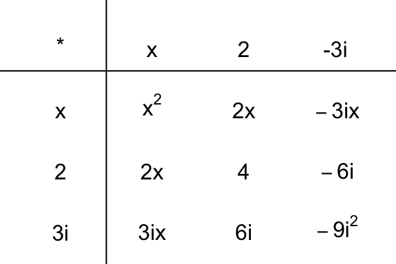

Notice some of those terms cancel.

$$f(x)~=~({7}x-{5})(x^2+4x+4-9i^2)$$

Remember that $i^2=-1$.

$$f(x)~=~({7}x-{5})(x^2+4x+4-9(-1))$$

$$f(x)~=~({7}x-{5})(x^2+4x+4+9)$$

$$f(x)~=~({7}x-{5})(x^2+4x+13)$$

Use another box to expand the product into standard form.

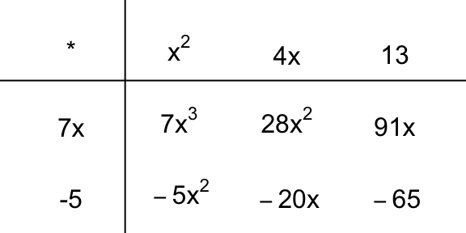

Combine like terms.

$$f(x)~=~{7}x^{3}+{23}x^{2}+{71}x-{65}$$

# Meta-information

extype: cloze exclozetype: schoice|schoice|schoice|schoice exsolution: 00000000000000000100000000000|00000000000000000000010000000|00000000000000000000000000100|00010000000000000000000000000 exname: x_standard_2_rat_1_comp